# Project Final

William Ma

May 22, 2019

# Data Science Tutorial

*Welcome to the world of data science! In this tutorial, we will go over important concepts that you will need to know as a data scientist. The topics we will go over includes: data wrangling (cleaning and unifying complex datasets for easy access and analysis), EDA (or Exploratory Data Analysis), Machine Learning (Linear Regression), and final discussion of the insights learned from analysis.*

# SAT Scores and Property Sales of New York City

This analysis will examine two datasets: SAT Scores of public schools and Property Sales, both located in New York City at relatively the same time. I would like to know if there is a direct correlation that can be established between these two attributes. This analysis will use cost of living (property price) within a borough as an indicator of wealth, and cumulative SAT scores (out of 2400) as an indicator of academic performance. I hope to prove with substantial data that there is a direct correlation between family wealth and academic performance.

## Ingest Data

The following datasets that I will use are labeled, “scores.csv” and “nyc-rolling-sales.csv”, both extracted from Kaggle.

```r
school_df <- read.csv(file="scores.csv", header=TRUE, sep=",")
property_df <- read.csv(file="nyc-rolling-sales.csv", header=TRUE, sep=",")

head(school_df)
```

```
##   School.ID                                                    School.Name
## 1    02M260                             Clinton School Writers and Artists
## 2    06M211   Inwood Early College for Health and Information Technologies
## 3    01M539 New Explorations into Science, Technology and Math High School
## 4    02M294                                           Essex Street Academy
## 5    02M308                                   Lower Manhattan Arts Academy
## 6    02M545                High School for Dual Language and Asian Studies
##     Borough Building.Code       Street.Address      City State Zip.Code
## 1 Manhattan          M933 425 West 33rd Street Manhattan    NY    10001
## 2 Manhattan          M052   650 Academy Street Manhattan    NY    10002
## 3 Manhattan          M022  111 Columbia Street Manhattan    NY    10002
## 4 Manhattan          M445     350 Grand Street Manhattan    NY    10002
## 5 Manhattan          M445     350 Grand Street Manhattan    NY    10002
## 6 Manhattan          M445     350 Grand Street Manhattan    NY    10002
##   Latitude Longitude   Phone.Number Start.Time End.Time Student.Enrollment
```

[output cut: 27 more lines]

```r
head(property_df)
```

```
##   X BOROUGH  NEIGHBORHOOD                     BUILDING.CLASS.CATEGORY
## 1 4       1 ALPHABET CITY 07 RENTALS - WALKUP APARTMENTS
## 2 5       1 ALPHABET CITY 07 RENTALS - WALKUP APARTMENTS
## 3 6       1 ALPHABET CITY 07 RENTALS - WALKUP APARTMENTS
## 4 7       1 ALPHABET CITY 07 RENTALS - WALKUP APARTMENTS
## 5 8       1 ALPHABET CITY 07 RENTALS - WALKUP APARTMENTS
## 6 9       1 ALPHABET CITY 07 RENTALS - WALKUP APARTMENTS
##   TAX.CLASS.AT.PRESENT BLOCK LOT EASE.MENT BUILDING.CLASS.AT.PRESENT
## 1                   2A   392   6        NA                        C2
## 2                    2   399  26        NA                        C7
## 3                    2   399  39        NA                        C7
## 4                   2B   402  21        NA                        C4
## 5                   2A   404  55        NA                        C2
## 6                    2   405  16        NA                        C4
##                  ADDRESS APARTMENT.NUMBER ZIP.CODE RESIDENTIAL.UNITS
```

[output cut: 27 more lines]

## Data Wrangling

### Tidy Property Data

NYC Property Sales dataset will be labeled ‘property_df’, which contains information about sales that had occurred in recent years, including the property price, boroughs the property is in, gross square feet, etc. The most important information we need in this dataset is the borough and property price. Afterwards, the data is manipulated as follows:

- First, we want to change the boroughs column to have actual names instead of numbers, so that we can join tables later for wrangling.
- Then, we will rename the variable for clarity.
- There are many ‘-’ indicating missing values under property price and gross square feet. We will replace them with the average of all property price or all gross square feet.
- There are also many 0’s in property prices. According to the datasource, $0 essentially means transfer of ownership, and this can harm our analysis. We will set all 0’s to the average of all property prices.
- We will create a new attribute “property level”, which categorizes the level of how much a property cost. This data will be used later in visualization.
- Many of the missing values are located property price and gross square feet. The best way to handle this data is to impute the empty slots with the average of their respective columns.

```r
property_df <- property_df %>%
    mutate(Borough = ifelse(BOROUGH == 1, 'Manhattan', ifelse(BOROUGH == 2, 'Bronx', ifelse(BOROUGH == 3, 'Brooklyn', ifelse(BOROUGH == 4, 'Queens', ifelse(BOROUGH == 5, 'Staten Island', NA)))))) %>%
  select(Borough, GROSS.SQUARE.FEET, SALE.PRICE) %>%
  rename(
    gross_sqr_ft = GROSS.SQUARE.FEET,
    property_price = SALE.PRICE
  )
property_df$Borough <- as.factor(property_df$Borough)
suppressWarnings(property_df$property_price <- as.numeric(as.character(property_df$property_price)))
suppressWarnings(property_df$gross_sqr_ft <- as.numeric(as.character(property_df$gross_sqr_ft)))

property_df[property_df == 0] <- NA

property_df <- property_df %>%
  mutate(property_level =
    ifelse(property_price >= 0 & property_price < 10000, "D", ifelse(property_price >= 10000 & property_price < 50000, "C", ifelse(property_price >= 50000 & property_price < 400000, "B", ifelse(property_price >= 400000, "A", NA))))
  ) %>%
  arrange(property_price)

property_df <- property_df %>%
  replace_na(list(property_price=mean(.$property_price, na.rm = TRUE))) %>%
  replace_na(list(gross_sqr_ft=mean(.$gross_sqr_ft, na.rm = TRUE)))

head(property_df)
```

```
##     Borough gross_sqr_ft property_price property_level
## 1 Manhattan     5060.445              1              D
## 2 Manhattan     5060.445              1              D
## 3 Manhattan     5060.445              1              D
## 4 Manhattan     5060.445              1              D
## 5 Manhattan     5060.445              1              D
## 6 Manhattan     5060.445              1              D
```

NYC Public School SAT Scores dataset will be labeled ‘school_df’, which contains information about SAT assessment performances that had occurred in recent years, including the reading, writing, and math scores, student demographic, borough, latitude, longitude, etc. The most important information we need in this dataset is the borough, SAT scores, and location (latitude, longitude). Afterwards, the data is manipulated as follows:

- First, we want to combine the average scores of each school’s SAT sections (reading, writing, and math) for our analysis. The cumulative score will be out of 2400.
- We will then rename for clarity
- We will create a new column that divides and categorizes a student’s SAT score. This will be used later in data visualization.
- All missing values are found in SAT scores, because some of these public schools do not require students to take the SAT, such as the school for the disabled. We will set their scores as the average.

```r
school_df <- school_df %>%
  select(School.ID, School.Name, Borough, Latitude, Longitude, Average.Score..SAT.Math., Average.Score..SAT.Reading., Average.Score..SAT.Writing.) %>%
  group_by(School.ID, School.Name, Borough, Latitude, Longitude) %>%
  summarize(sat_score = sum(Average.Score..SAT.Math., Average.Score..SAT.Writing., Average.Score..SAT.Reading.)) %>%
  rename(
    school_id = School.ID,
    school_name = School.Name
  ) %>%
  mutate(score_level =
    ifelse(sat_score >= 0 && sat_score < 600, "D", ifelse(sat_score >= 600 && sat_score < 1200, "C", ifelse(sat_score >= 1200 && sat_score < 1800, "B", ifelse(sat_score >= 1800 && sat_score <= 2400, "A", NA))))
  )
school_df <- school_df %>%
  replace_na(list(sat_score=mean(.$sat_score, na.rm = TRUE))) %>%
  replace_na(list(score_level='D'))
head(school_df)
```

```
## # A tibble: 6 x 7
## # Groups:   school_id, school_name, Borough, Latitude [6]
##   school_id school_name    Borough Latitude Longitude sat_score score_level
##   <fct>     <fct>          <fct>      <dbl>     <dbl>     <dbl> <chr>
## 1 01M292    Henry Street ~ Manhat~     40.7     -74.0      1197 C
## 2 01M448    University Ne~ Manhat~     40.7     -74.0      1144 C
## 3 01M450    East Side Com~ Manhat~     40.7     -74.0      1327 B
## 4 01M509    Marta Valle H~ Manhat~     40.7     -74.0      1245 B
## 5 01M539    New Explorati~ Manhat~     40.7     -74.0      1859 A
## 6 01M696    Bard High Sch~ Manhat~     40.7     -74.0      1914 A
```

### Combining datasets

We will now combine both school_df and property_df via left_join. The join will matched by the ‘Borough’ column. Also, it is important to note that property prices have been filtered down to between 1,000 and 500,000 USD. The purpose for this is because of the wide range of housing cost that exists in New York City. As mentioned earlier, many property prices were $0 due to transferring ownership between family members. There were thousands of that specific case. Also there were many outliers that existed beyond millions of dollars in property value. The difference in price is astronomical and will definitely harm the analysis. We are also taking a small sample of the dataset due to the sheer amount of entities that exists.

```r
borough_df <- school_df %>%
  left_join(property_df, by='Borough') %>%
  group_by(Borough) %>%
  filter(property_price >= 1000 & property_price <= 500000) %>%
  sample_frac(.01)
borough_df
```

```
## # A tibble: 18,964 x 10
## # Groups:   Borough [5]
##    school_id school_name Borough Latitude Longitude sat_score score_level
##    <fct>     <fct>       <fct>      <dbl>     <dbl>     <dbl> <chr>
##  1 08X559    School for~ Bronx       40.8     -73.9     1276. D
##  2 08X376    Antonia Pa~ Bronx       40.8     -73.9     1273  B
##  3 08X305    Pablo Neru~ Bronx       40.8     -73.9     1161  C
##  4 12X248    Metropolit~ Bronx       40.8     -73.9     1161  C
##  5 09X517    Frederick ~ Bronx       40.8     -73.9     1159  C
##  6 09X327    Comprehens~ Bronx       40.8     -73.9     1276. D
##  7 08X349    Bronx Rive~ Bronx       40.8     -73.8     1276. D
##  8 11X509    High Schoo~ Bronx       40.9     -73.9     1016  C
##  9 07X600    Alfred E. ~ Bronx       40.8     -73.9     1134  C
## 10 10X351    Bronx Coll~ Bronx       40.9     -73.9     1276. D
## # ... with 18,954 more rows, and 3 more variables: gross_sqr_ft <dbl>,
## #   property_price <dbl>, property_level <chr>
```

We are now ready for our EDA!

## Exploratory Data Analysis (EDA)

### SAT Score Distribution across NYC Boroughs

In this first plot, we want to see the data distribution across each NYC borough and observe difference in central tendency. The SAT score is scored out of 2400.

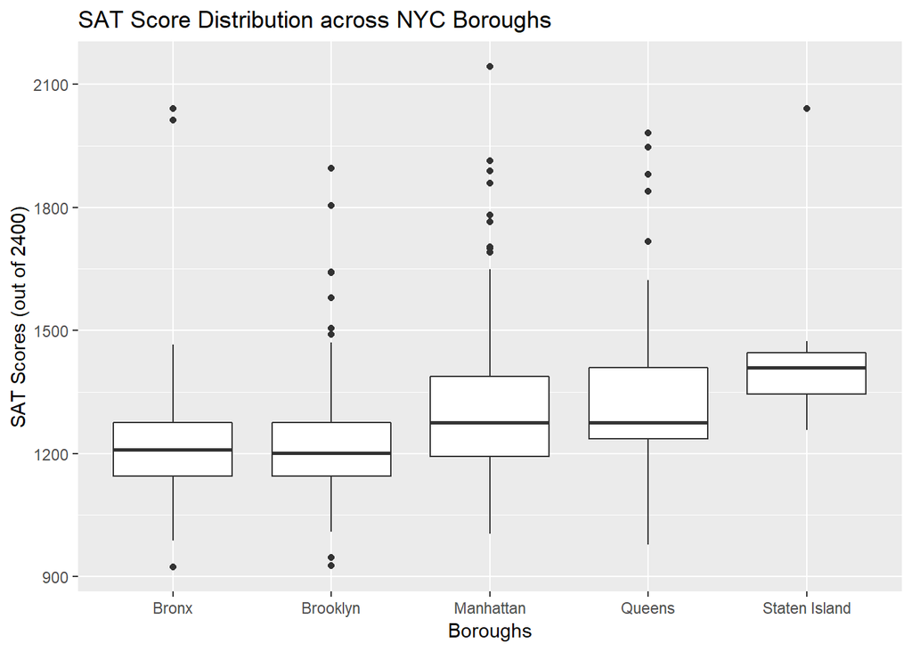

```r
eda1_boxplot <- borough_df %>%
  rowid_to_column() %>%
  ggplot(mapping = aes(x=factor(Borough), y=sat_score)) +
  geom_boxplot() +
  labs(title="SAT Score Distribution across NYC Boroughs",
  x = "Boroughs",
  y = "SAT Scores (out of 2400)")
eda1_boxplot
```

We can see that there are outliers in every borough. In terms of highest scores when comparing the median, Staten Island comes first. The highest score overall goes to a school in Manhattan. Let us now look at the Property Prices Distribution across the NYC Boroughs…

### Property Price Distribution across NYC Boroughs

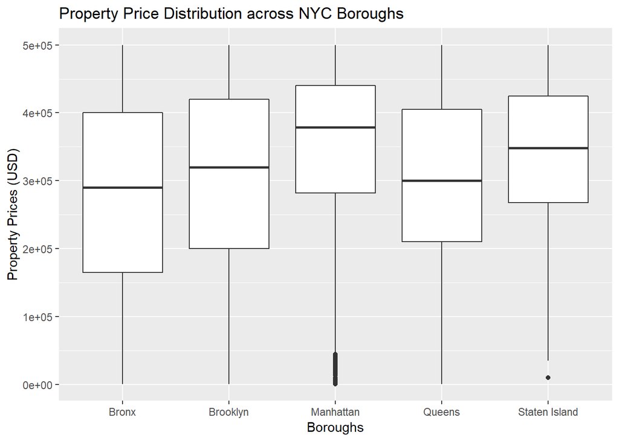

```r
eda1_boxplot <- borough_df %>%
  rowid_to_column() %>%
  ggplot(mapping = aes(x=factor(Borough), y=property_price)) +
  geom_boxplot() +
  labs(title="Property Price Distribution across NYC Boroughs",
  x = "Boroughs",
  y = "Property Prices (USD)")
eda1_boxplot
```

Based on these plots, we can see that the median property price of Manhattan is the highest compared to the rest, indicating that this borough is the wealthiest.

Now let’s answer the million dollar question, is property price (wealth) directly correlated to SAT scores (academic performance)? We will now create a scatter plot for these two numeric attributes:

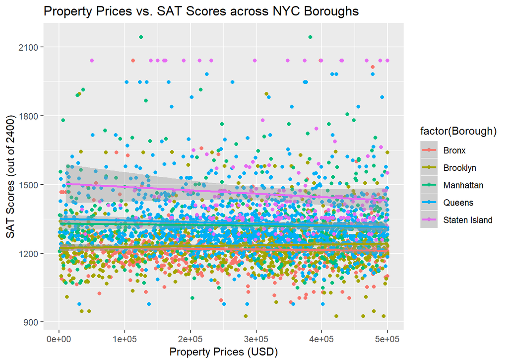

```r
eda1_scatter <- borough_df %>%
  rowid_to_column() %>%
  group_by(Borough, property_price) %>%
  summarize(mean_score = mean(sat_score)) %>%
  ggplot(mapping=aes(y=mean_score, x=property_price, color=factor(Borough))) +
  geom_point() + geom_smooth(method=lm) +
  labs(title="Property Prices vs. SAT Scores across NYC Boroughs",
  x = "Property Prices (USD)",
  y = "SAT Scores (out of 2400)")
eda1_scatter
```

The graph above depicts all the data points of SAT scores and property prices, each point colored with their specific borough. This graph is ugly and overwhelming. Let’s try to make it easier to look at and get a better grasp of the data we see.

We will now plot the same graph. But this time, instead of color coding our boroughs, we will now facet our visualization. This means that we will create different graphs, splitting based on conditions we have set. In this case, we are splitting based on different boroughs.

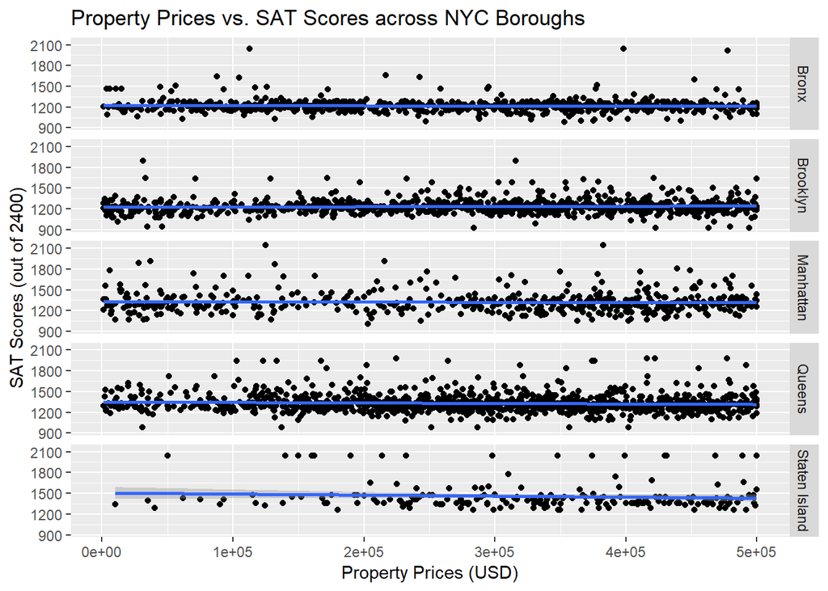

```r
eda1_scatter <- borough_df %>%
  rowid_to_column() %>%
  group_by(Borough, property_price) %>%
  summarize(mean_score = mean(sat_score)) %>%
  ggplot(mapping=aes(y=mean_score, x=property_price)) +
  facet_grid(Borough~.) +
  geom_point() + geom_smooth(method=lm) +
  labs(title="Property Prices vs. SAT Scores across NYC Boroughs",
  x = "Property Prices (USD)",
  y = "SAT Scores (out of 2400)")
eda1_scatter
```

The graphs are now easier to look at. We will take it one step further and graph each borough individually. The reason is to examine the linear regression, and plot residual graphs to determine if the linear relationship is a good approximation.

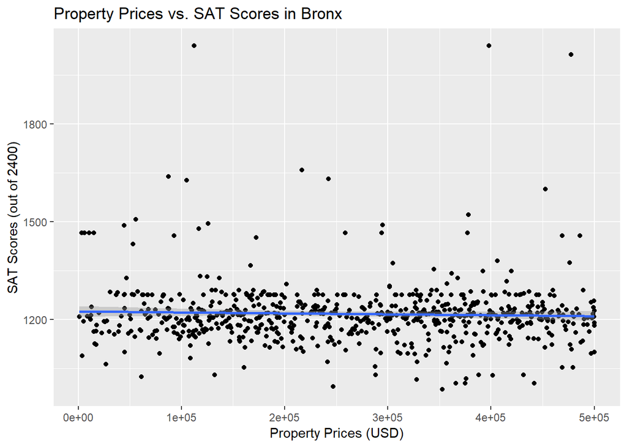

```r
bronx_scatter <- borough_df %>%
  filter(Borough == 'Bronx') %>%
  rowid_to_column() %>%
  group_by(Borough, property_price) %>%
  summarize(mean_score = mean(sat_score)) %>%
  ggplot(mapping=aes(y=mean_score, x=property_price)) +
  geom_point() + geom_smooth(method=lm) +
  labs(title="Property Prices vs. SAT Scores in Bronx",
  x = "Property Prices (USD)",
  y = "SAT Scores (out of 2400)")
bronx_scatter
```

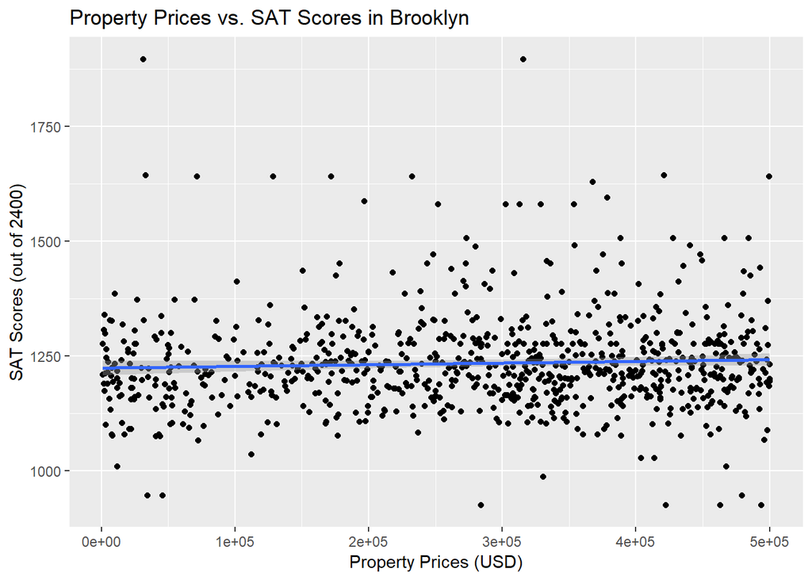

```r
brooklyn_scatter <- borough_df %>%
  filter(Borough == 'Brooklyn') %>%
  rowid_to_column() %>%
  group_by(Borough, property_price) %>%
  summarize(mean_score = mean(sat_score)) %>%
  ggplot(mapping=aes(y=mean_score, x=property_price)) +
  geom_point() + geom_smooth(method=lm) +
  labs(title="Property Prices vs. SAT Scores in Brooklyn",
  x = "Property Prices (USD)",
  y = "SAT Scores (out of 2400)")
brooklyn_scatter
```

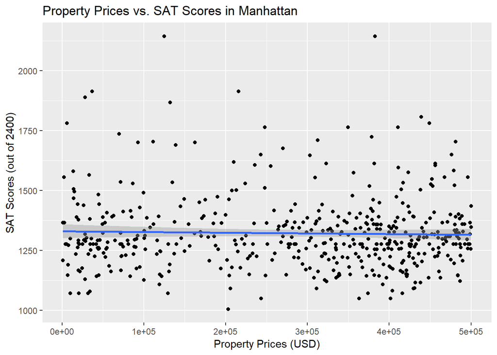

```r
manhattan_scatter <- borough_df %>%
  filter(Borough == 'Manhattan') %>%
  rowid_to_column() %>%
  group_by(Borough, property_price) %>%
  summarize(mean_score = mean(sat_score)) %>%
  ggplot(mapping=aes(y=mean_score, x=property_price)) +
  geom_point() + geom_smooth(method=lm) +
  labs(title="Property Prices vs. SAT Scores in Manhattan",
  x = "Property Prices (USD)",
  y = "SAT Scores (out of 2400)")
manhattan_scatter
```

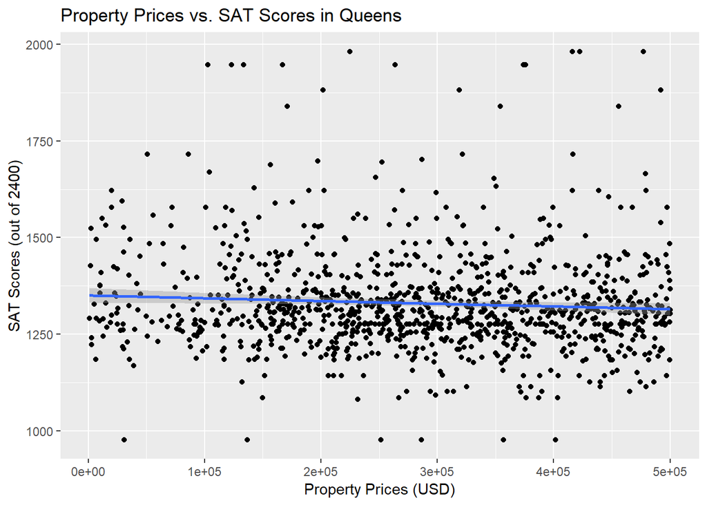

```r
queens_scatter <- borough_df %>%
  filter(Borough == 'Queens') %>%
  rowid_to_column() %>%
  group_by(Borough, property_price) %>%
  summarize(mean_score = mean(sat_score)) %>%
  ggplot(mapping=aes(y=mean_score, x=property_price)) +
  geom_point() + geom_smooth(method=lm) +
  labs(title="Property Prices vs. SAT Scores in Queens",
  x = "Property Prices (USD)",
  y = "SAT Scores (out of 2400)")
queens_scatter
```

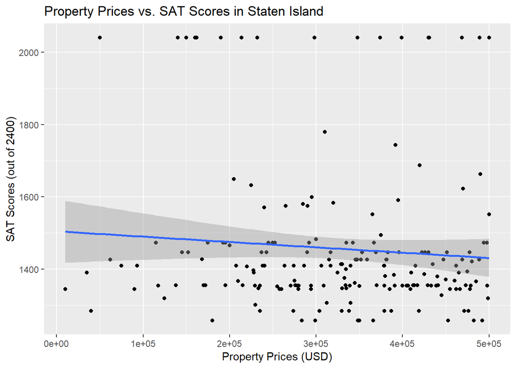

```r
staten_scatter <- borough_df %>%
  filter(Borough == 'Staten Island') %>%
  rowid_to_column() %>%
  group_by(Borough, property_price) %>%
  summarize(mean_score = mean(sat_score)) %>%
  ggplot(mapping=aes(y=mean_score, x=property_price)) +
  geom_point() + geom_smooth(method=lm) +
  labs(title="Property Prices vs. SAT Scores in Staten Island",
  x = "Property Prices (USD)",
  y = "SAT Scores (out of 2400)")
staten_scatter
```

## Residual Graphs

We will confirm that the linear relationship is a good approximation by plotting the residuals against property prices for each borough.

```r
bronx_data <- borough_df %>%
  filter(Borough == 'Bronx') %>%
  rowid_to_column() %>%
  group_by(Borough, property_price) %>%
  summarize(mean_score = mean(sat_score))

bronx_res <- lm(formula = mean_score~property_price, data = bronx_data)
tidy(bronx_res)
```

```
## # A tibble: 2 x 5
##   term                estimate std.error statistic p.value
##   <chr>                  <dbl>     <dbl>     <dbl>   <dbl>
## 1 (Intercept)     1225.        8.18         150.     0
## 2 property_price    -0.0000287 0.0000276     -1.04   0.300
```

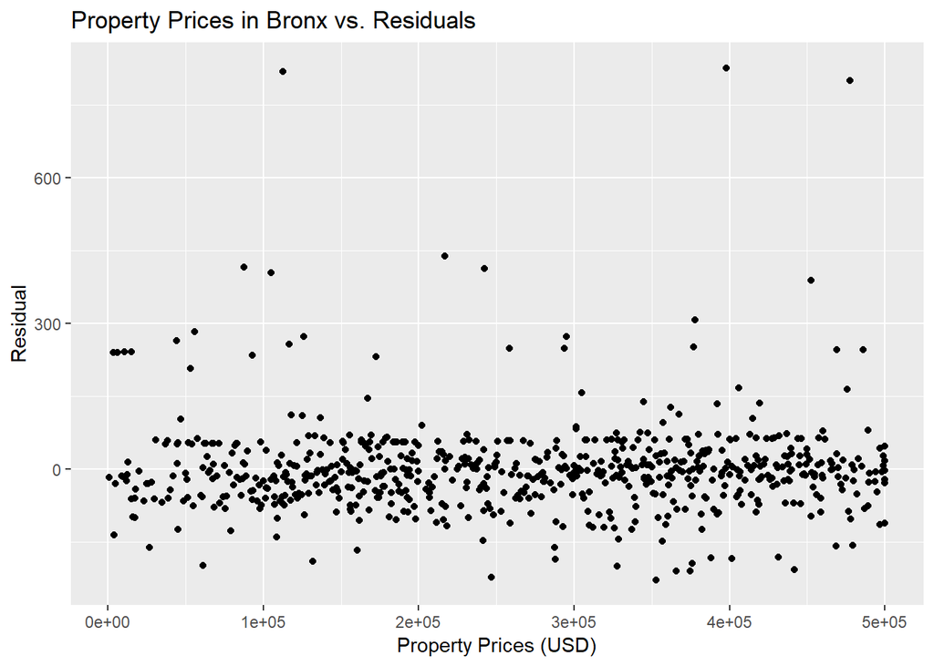

```r
bronx_res <- bronx_res %>%
  augment() %>%
  ggplot(mapping = aes(x=property_price, y=.resid)) +
  geom_point() +
  labs(title="Property Prices in Bronx vs. Residuals",
  x = "Property Prices (USD)",
  y = "Residual")
bronx_res
```

```r
brooklyn_data <- borough_df %>%
  filter(Borough == 'Brooklyn') %>%
  rowid_to_column() %>%
  group_by(Borough, property_price) %>%
  summarize(mean_score = mean(sat_score))

brooklyn_res <- lm(formula = mean_score~property_price, data = brooklyn_data)
tidy(brooklyn_res)
```

```
## # A tibble: 2 x 5
##   term               estimate std.error statistic p.value
##   <chr>                 <dbl>     <dbl>     <dbl>   <dbl>
## 1 (Intercept)    1224.        8.05         152.     0
## 2 property_price    0.0000363 0.0000255      1.42   0.155
```

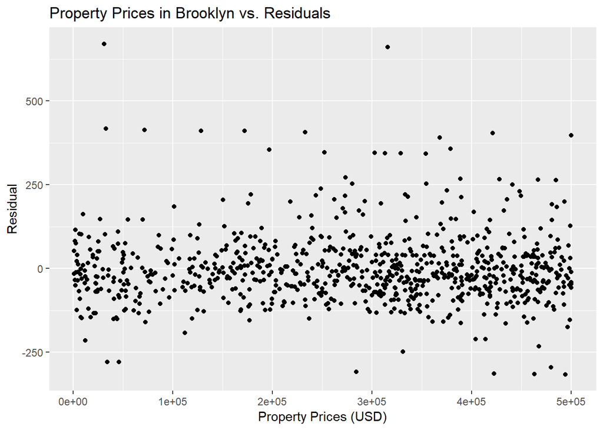

```r
brooklyn_res <- brooklyn_res %>%
  augment() %>%
  ggplot(mapping = aes(x=property_price, y=.resid)) +
  geom_point() +
  labs(title="Property Prices in Brooklyn vs. Residuals",
  x = "Property Prices (USD)",
  y = "Residual")
brooklyn_res
```

```r
manhattan_data <- borough_df %>%
  filter(Borough == 'Manhattan') %>%
  rowid_to_column() %>%
  group_by(Borough, property_price) %>%
  summarize(mean_score = mean(sat_score))

manhattan_res <- lm(formula = mean_score~property_price, data = manhattan_data)
tidy(manhattan_res)
```

```
## # A tibble: 2 x 5
##   term                estimate  std.error statistic   p.value
##   <chr>                  <dbl>      <dbl>     <dbl>     <dbl>
## 1 (Intercept)     1330.        14.6          91.0   6.91e-307
## 2 property_price    -0.0000287  0.0000455    -0.631 5.28e-  1
```

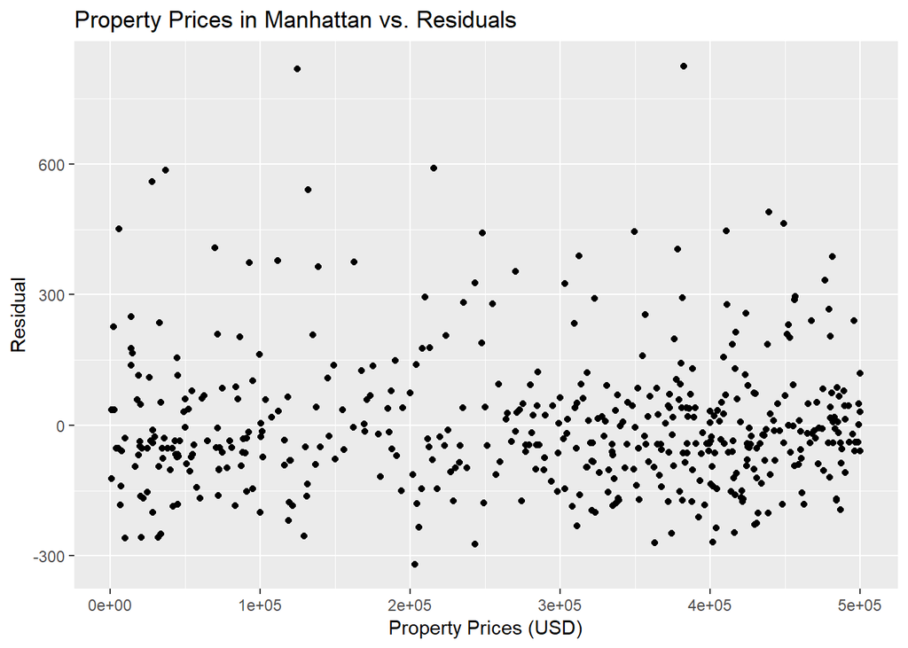

```r
manhattan_res <- manhattan_res %>%
  augment() %>%
  ggplot(mapping = aes(x=property_price, y=.resid)) +
  geom_point() +
  labs(title="Property Prices in Manhattan vs. Residuals",
  x = "Property Prices (USD)",
  y = "Residual")
manhattan_res
```

```r
queens_data <- borough_df %>%
  filter(Borough == 'Queens') %>%
  rowid_to_column() %>%
  group_by(Borough, property_price) %>%
  summarize(mean_score = mean(sat_score))

queens_res <- lm(formula = mean_score~property_price, data = queens_data)
tidy(queens_res)
```

```
## # A tibble: 2 x 5
##   term                estimate std.error statistic p.value
##   <chr>                  <dbl>     <dbl>     <dbl>   <dbl>
## 1 (Intercept)     1351.        9.72         139.    0
## 2 property_price    -0.0000708 0.0000311     -2.28  0.0230
```

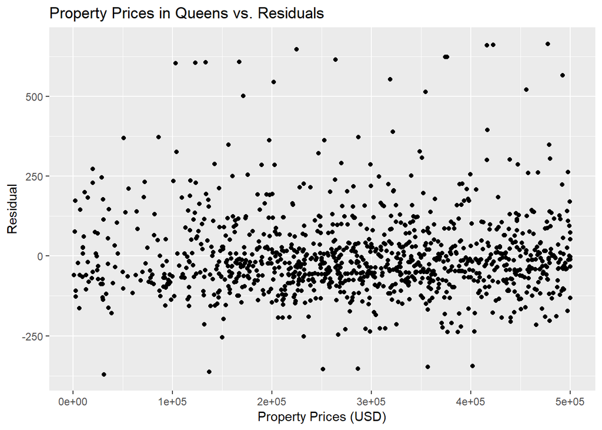

```r
queens_res <- queens_res %>%
  augment() %>%
  ggplot(mapping = aes(x=property_price, y=.resid)) +
  geom_point() +
  labs(title="Property Prices in Queens vs. Residuals",
  x = "Property Prices (USD)",
  y = "Residual")
queens_res
```

```r
staten_data <- borough_df %>%
  filter(Borough == 'Staten Island') %>%
  rowid_to_column() %>%
  group_by(Borough, property_price) %>%
  summarize(mean_score = mean(sat_score))

staten_res <- lm(formula = mean_score~property_price, data = staten_data)
tidy(staten_res)
```

```
## # A tibble: 2 x 5
##   term               estimate std.error statistic  p.value
##   <chr>                 <dbl>     <dbl>     <dbl>    <dbl>
## 1 (Intercept)     1505.       44.6          33.7  4.05e-82
## 2 property_price    -0.000148  0.000129     -1.14 2.54e- 1
```

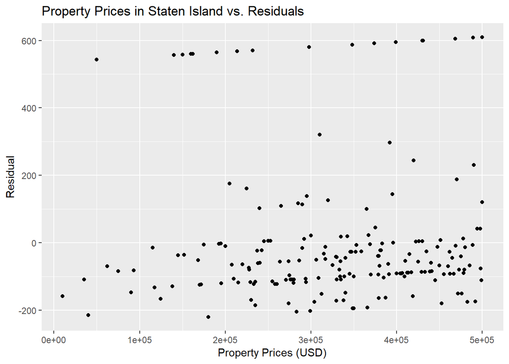

```r
staten_res <- staten_res %>%
  augment() %>%
  ggplot(mapping = aes(x=property_price, y=.resid)) +
  geom_point() +
  labs(title="Property Prices in Staten Island vs. Residuals",
  x = "Property Prices (USD)",
  y = "Residual")
staten_res
```

### Leaflet

In this section, we will create visualizations of our data point using Leaflet. First we will set up our latitude and longitude on NYC.

```r
nyc_map <- leaflet(borough_df) %>%
 addTiles() %>%
 setView(lat=40.73, lng=-73.93, zoom=13)
nyc_map
```

[interactive chart not shown]

We are now ready to input data. In this first implementation, we will simply mark all data points based on boroughs.

```r
pal <- colorFactor(c("green","yellow", "orange", "red", "black"), domain = c("Bronx", "Brooklyn", "Manhattan", "Queens", "Staten Island"))
leaflet(borough_df) %>% addTiles() %>%
 addCircleMarkers(
 radius = 8,
 color = ~pal(Borough),
 stroke = FALSE, fillOpacity = 0.8
 )
```

```
## Assuming "Longitude" and "Latitude" are longitude and latitude, respectively
```

[interactive chart not shown]

Remember the score_level we made in the beginning of the tutorial? We will use that column to color code the various SAT scores in NYC.

```r
pal <- colorFactor(c("green","yellow", "red", "black"), domain = c("A", "B", "C", "D"))
leaflet(borough_df) %>% addTiles() %>%
 addCircleMarkers(
 radius = 5,
 color = ~pal(score_level),
 stroke = FALSE, fillOpacity = 0.8
 )
```

```
## Assuming "Longitude" and "Latitude" are longitude and latitude, respectively
```

[interactive chart not shown]

Just like the score_level, property_level will be used for visualization, categorizing the properties based on grades determined at the beginning of this tutorial.

```r
pal <- colorFactor(c("green","yellow", "red", "black"), domain = c("A", "B", "C", "D"))
leaflet(borough_df) %>% addTiles() %>%
 addCircleMarkers(
 radius = 5,
 color = ~pal(property_level),
 stroke = FALSE, fillOpacity = 0.6
 )
```

```
## Assuming "Longitude" and "Latitude" are longitude and latitude, respectively
```

[interactive chart not shown]

## Discussion

Any further research that would like to find the correlation between individual wealth and academic performance should take these possibilities into consideration.

This concludes the analysis between SAT scores and Property Sales in NYC.

## Datasets Credits:

[Average SAT Scores for NYC Public Schools dataset] was compiled and published by the New York City Department of Education, and the SAT score averages and testing rates were provided by the College Board. https://www.kaggle.com/nycopendata/high-schools

[NYC Property Sales dataset] is a concatenated and slightly cleaned-up version of the New York City Department of Finance’s Rolling Sales dataset. https://www.kaggle.com/new-york-city/nyc-property-sales